# CW1_13154855_A_Guo

Anyi Guo

16/10/2018

1. Statistical learning methods

For each of parts (a) through (d), indicate whether we would generally expect the performance of a flexible statistical learning method to be better or worse than an inflexible method. Justify your answer.

- The sample size n is extremely large, and the number of predictors p is small.

**Answer**: Flexible method would work better. This is because the large sample size means that it’s less likely for us to overfit the data. Flexible methods also tends to reduce bias.

- The number of predictors p is extremely large, and the number of observations n is small.

**Answer**: Inflexible method would work better. A flexible method is likely to cause overfitting in this instance.

- The relationship between the predictors and response is highly non-linear.

**Answer**: A flexible model would work better. This is because we need to use its flexibility to fit the non-linear nature of the data.

- The variance of the error terms, i.e. σ2 = Var(ε), is extremely high.

**Answer**: An inflexible model would work better. This is because a flexible model would easily overfit the model and conveys too much noise due to the large variance in errors.

2. Descriptive analysis

In a higher educational institution the comprehensive applied mathematics exam is comprised of two parts. On the first day, 20 students took the exam, the results of which are presented below:

Oral exam results: 4, 1, 4, 5, 3, 2, 3, 4, 3, 5, 2, 2, 4, 3, 5, 5, 1, 1, 1, 2.  
Written exam results: 2,3,1,4,2,5,3,1,2,1,2,2,1,1,2,3,1,2,3,4.

- Use R to calculate the mean, the mode, the median, the variance and the standard deviation of the oral and written exams separately and together as well.

```r
oral<-c(4, 1, 4, 5, 3, 2, 3, 4, 3, 5, 2, 2, 4, 3, 5, 5, 1, 1, 1, 2)
written<-c(2,3,1,4,2,5,3,1,2,1,2,2,1,1,2,3,1,2,3,4)
combined <-c(oral,written)

findmode <- function(i) {
   uniqi <- unique(i)
   uniqi[which.max(tabulate(match(i, uniqi)))]
}

exam <- matrix(nrow=3,ncol=5)
colnames(exam)=c("Mean","Mode","Median","Variance","Std Deviation")
rownames(exam)=c("Oral","Written","Combined")
exam[1,]<-c(mean(oral),findmode(oral),median(oral),var(oral),sd(oral))
exam[2,]<-c(mean(written),findmode(written),median(written),var(written),sd(written))
exam[3,]<-c(mean(combined),findmode(combined),median(combined),var(combined),sd(combined))
```

2. Find the covariance and correlation between the oral and written exam scores.

```r
print(cov(oral,written))
```

```
## [1] -0.3157895
```

```r
print(cor(oral,written))
```

```
## [1] -0.1869531
```

3. Is there a positive or negative or no correlation between the two?

**Answer**:There is a slightly negative correlation between the two.

4. Is there causation between the two? Justify your answers.

**Answer**:Not sure. Correlation does not necessarily signify causation - we’ll need more data to substantiate that claim.

3. Descriptive analysis This exercise involves the Auto data set studied in the class. Make sure that the missing values have been removed from the data.
1. Which of the predictors are quantitative, and which are qualitative?

**Answer**: * Quantitative: `mpg`, `cylinders`,`displacement`, `horsepower`, `weight`, `acceleration`,`year` * Qualitative: `origin`, `name`

```r
library(ISLR)
Auto<-na.omit(Auto)
```

2. What is the range of each quantitative predictor? You can answer this using the range() function.

```r
# Get range for each column
for(i in 1:7){
        print(paste("The range for", colnames(Auto)[i], "is", range(Auto[,i])[1],"~",range(Auto[,i])[2]))
        }
```

```
## [1] "The range for mpg is 9 ~ 46.6"
## [1] "The range for cylinders is 3 ~ 8"
## [1] "The range for displacement is 68 ~ 455"
## [1] "The range for horsepower is 46 ~ 230"
## [1] "The range for weight is 1613 ~ 5140"
## [1] "The range for acceleration is 8 ~ 24.8"
## [1] "The range for year is 70 ~ 82"
```

3. What is the mean and standard deviation of each quantitative predictor?

```r
# get Mean for each column
for(i in 1:7){
        print(paste("The mean for", colnames(Auto)[i], "is", mean(Auto[,i])))
}
```

```
## [1] "The mean for mpg is 23.4459183673469"
## [1] "The mean for cylinders is 5.4719387755102"
## [1] "The mean for displacement is 194.411989795918"
## [1] "The mean for horsepower is 104.469387755102"
## [1] "The mean for weight is 2977.58418367347"
## [1] "The mean for acceleration is 15.5413265306122"
## [1] "The mean for year is 75.9795918367347"
```

```r
# get Standard Deviation for each column

for(i in 1:7){
        print(paste("The standard deviation for",colnames(Auto)[i],"is",sd(Auto[,i])))
}
```

```
## [1] "The standard deviation for mpg is 7.8050074865718"
## [1] "The standard deviation for cylinders is 1.70578324745278"
## [1] "The standard deviation for displacement is 104.644003908905"
## [1] "The standard deviation for horsepower is 38.4911599328285"
## [1] "The standard deviation for weight is 849.402560042949"
## [1] "The standard deviation for acceleration is 2.75886411918808"
## [1] "The standard deviation for year is 3.68373654357783"
```

4. Now remove the 10th through 85th observations. What is the range, mean, and standard deviation of each predictor in the subset of the data that remains?

```r
newAuto<-Auto[-seq(10,85)]

for(i in 1:7){
        print(paste("In the subset newAuto, the range for", colnames(newAuto)[i], "is", range(newAuto[,i])[1],"~",range(newAuto[,i])[2],", the mean is",mean(newAuto[,i]), ", the standard deviation is",sd(newAuto[,i])))
}
```

```
## [1] "In the subset newAuto, the range for mpg is 9 ~ 46.6 , the mean is 23.4459183673469 , the standard deviation is 7.8050074865718"
## [1] "In the subset newAuto, the range for cylinders is 3 ~ 8 , the mean is 5.4719387755102 , the standard deviation is 1.70578324745278"
## [1] "In the subset newAuto, the range for displacement is 68 ~ 455 , the mean is 194.411989795918 , the standard deviation is 104.644003908905"
## [1] "In the subset newAuto, the range for horsepower is 46 ~ 230 , the mean is 104.469387755102 , the standard deviation is 38.4911599328285"
## [1] "In the subset newAuto, the range for weight is 1613 ~ 5140 , the mean is 2977.58418367347 , the standard deviation is 849.402560042949"
## [1] "In the subset newAuto, the range for acceleration is 8 ~ 24.8 , the mean is 15.5413265306122 , the standard deviation is 2.75886411918808"
## [1] "In the subset newAuto, the range for year is 70 ~ 82 , the mean is 75.9795918367347 , the standard deviation is 3.68373654357783"
```

5. Using the full data set, investigate the predictors graphically, using scatterplots or other tools of your choice. Create some plots highlighting the relationships among the predictors. Comment on your findings.

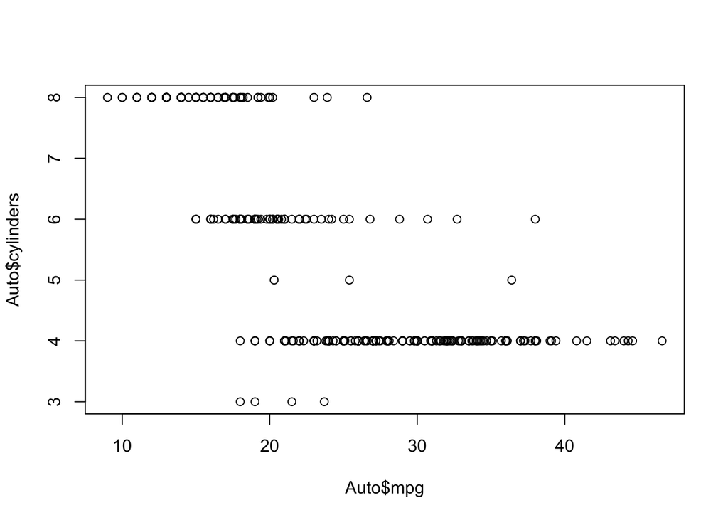

```r
plot(Auto$mpg,Auto$cylinders)
```

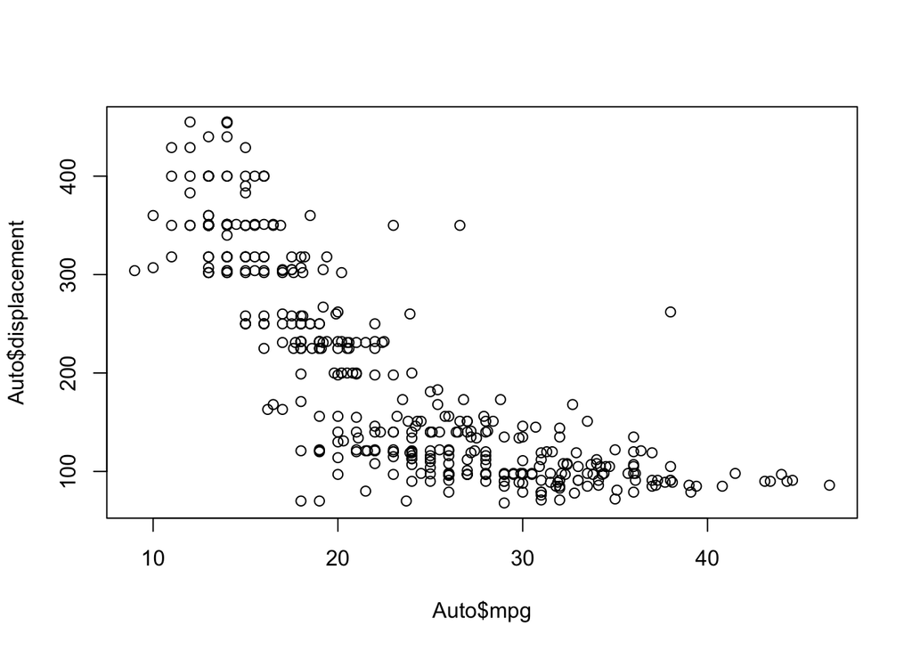

```r
# the higher the mpg, the lower the number of cylinders. Number of cylinders is not continuous.

plot(Auto$mpg,Auto$displacement) # there seems to be a negative polynomial correlation between mpg and displacement
```

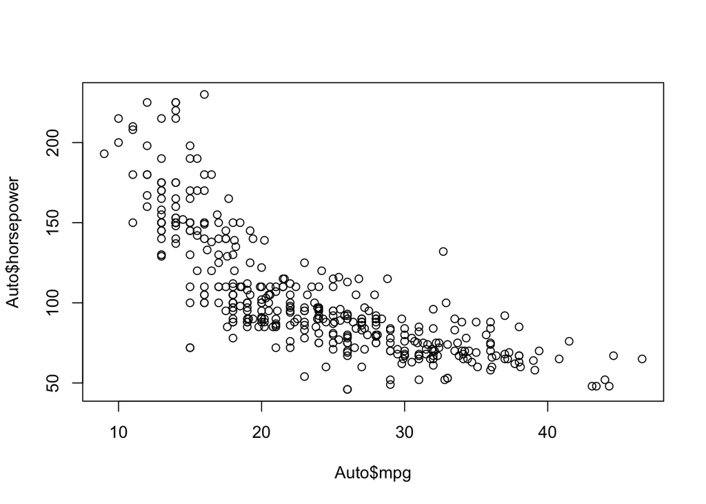

```r
plot(Auto$mpg,Auto$horsepower) # this chart seems to indicate a negative linear/polynomial correlation between mpg and horsepower
```

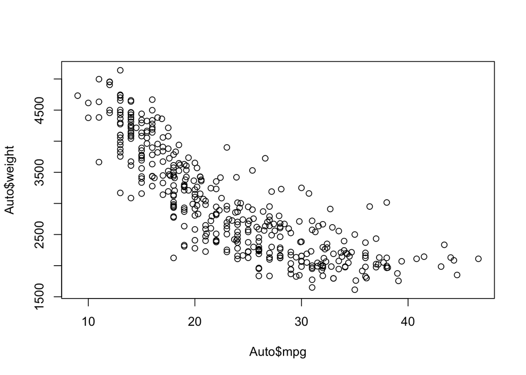

```r
plot(Auto$mpg,Auto$weight) # seems to be a negative linear(?)correlation between mpg and weight
```

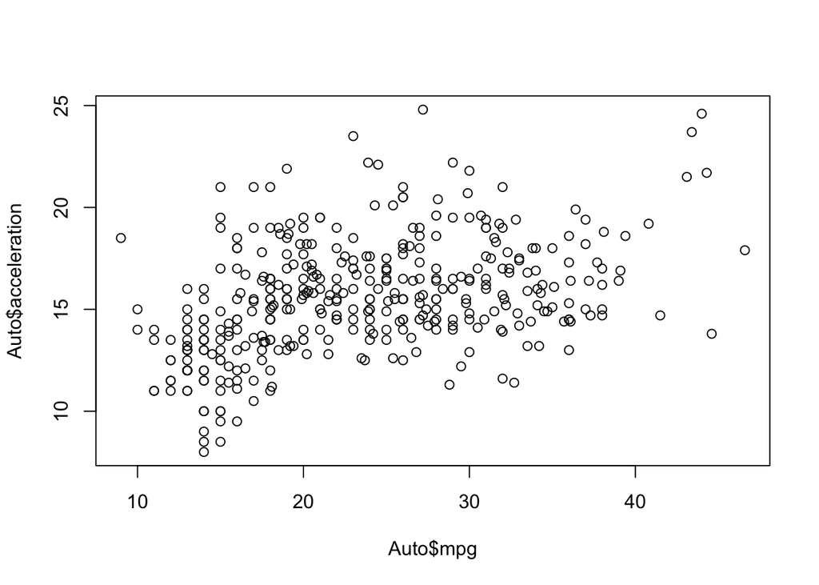

```r
plot(Auto$mpg,Auto$acceleration) # this chart seems to indicate a positive linear/polynomial relationship between mpg and acceleration
```

6. Suppose that we wish to predict gas mileage (mpg) on the basis of the other variables. Do your plots suggest that any of the other variables might be useful in predicting mpg? Justify your answer.

**Answer**: In addition to the 5 quantitative columns, the `Origin` and `Year` column may also be useful in predicting mpg.

`Origin`: the higher the number (i.e. Japanese>European>America), the higher the mpg tends to be.

`Year`: the later the year, the higher the mpg tends to be.

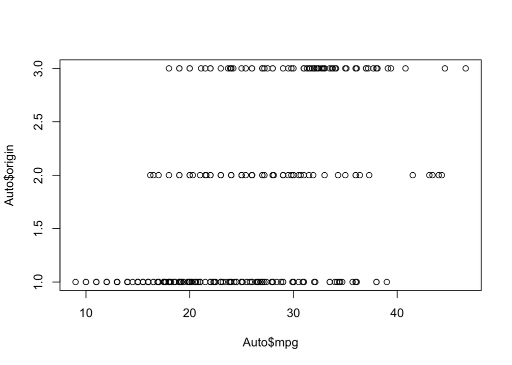

```r
plot(Auto$mpg,Auto$origin)
```

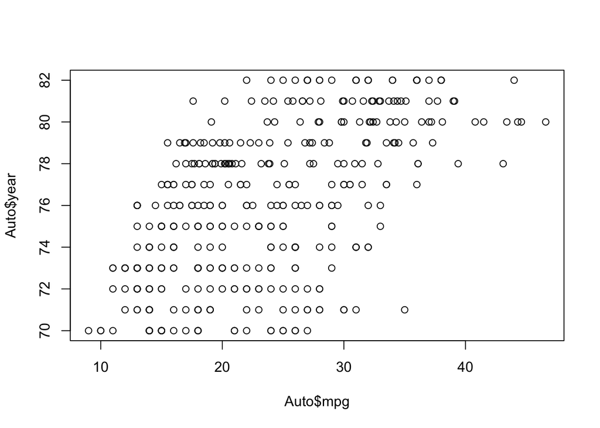

```r
plot(Auto$mpg,Auto$year)
```

4. Linear regression This question involves the use of simple linear regression on the Auto data set.
1. Use the lm() function to perform a simple linear regression with mpg as the response and horsepower as the predictor. Use the summary() function to print the results. Comment on the output. For example:

```r
lm.fit<-lm(mpg~horsepower,data=Auto)
summary(lm.fit)
```

```
##
## Call:
## lm(formula = mpg ~ horsepower, data = Auto)
##
## Residuals:
##      Min       1Q   Median       3Q      Max
## -13.5710  -3.2592  -0.3435   2.7630  16.9240
##
## Coefficients:
##              Estimate Std. Error t value Pr(>|t|)
## (Intercept) 39.935861   0.717499   55.66   <2e-16 ***
## horsepower  -0.157845   0.006446  -24.49   <2e-16 ***
## ---
## Signif. codes:  0 '***' 0.001 '**' 0.01 '*' 0.05 '.' 0.1 ' ' 1
##
## Residual standard error: 4.906 on 390 degrees of freedom
## Multiple R-squared:  0.6059, Adjusted R-squared:  0.6049
## F-statistic: 599.7 on 1 and 390 DF,  p-value: < 2.2e-16
```

1. Is there a relationship between the predictor and the response?  
   **Answer**: Yes, there is a statistically significant relationship between the predictor and response(i.e. the null hypothesis is rejected)
2. How strong is the relationship between the predictor and the response?  
   **Answer**: The relationship is strong (i.e. above significance level, both have three *** signs)
3. Is the relationship between the predictor and the response positive or negative?  
   **Answer**:Negative.
4. What is the predicted mpg associated with a horsepower of 98? What are the associated 95% confidence and prediction intervals?

```r
print(paste("Confidence interval is",predict(lm.fit,data.frame(horsepower=98),interval="confidence")))
```

```
## [1] "Confidence interval is 24.4670771525124"
## [2] "Confidence interval is 23.9730789607039"
## [3] "Confidence interval is 24.9610753443209"
```

```r
print(paste("Prediction is",predict(lm.fit,data.frame(horsepower=98),interval="prediction")))
```

```
## [1] "Prediction is 24.4670771525124" "Prediction is 14.8093960709667"
## [3] "Prediction is 34.1247582340581"
```

2. Plot the response and the predictor. Use the abline() function to display the least squares regression line.

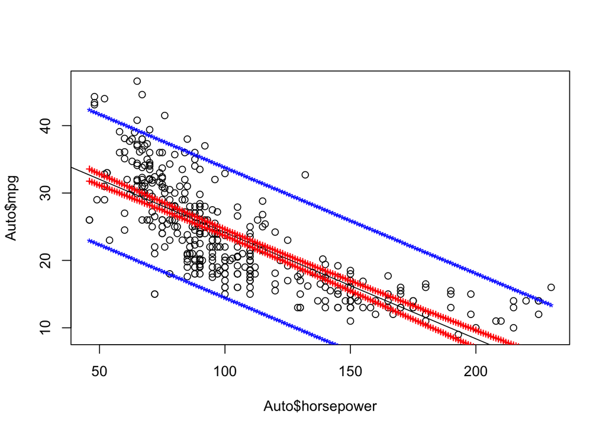

```r
lm.fit<-lm(mpg~horsepower,data=Auto)
nd <- data.frame(horsepower=seq(46,230))
p_conf <- predict(lm.fit,interval="confidence",newdata=nd)
p_pred <- predict(lm.fit,interval="prediction",newdata=nd)

plot(Auto$horsepower,Auto$mpg)
abline(lm.fit)

lines(nd$horse, p_conf[,"lwr"], col="red", type="b", pch="+")
lines(nd$horse, p_conf[,"upr"], col="red", type="b", pch="+")
lines(nd$horse, p_pred[,"upr"], col="blue", type="b", pch="*")
lines(nd$horse, p_pred[,"lwr"], col="blue", type="b", pch="*")
```

3. Plot the 95% confidence interval and prediction interval in the same plot as (b) using different colours and legends.

**Answer**: Please see above chart.

5. Logistic regression Using the Boston data set, fit classification models in order to predict whether a given suburb has a crime rate above or below the median. Explore logistic regression models using various subsets of the predictors. Describe your findings.

**Answer**: Using `crim` as the response, there are 13 variables in the Boston dataset which can be used as predictors. We’ll devide them into 3 sets and run logistic regrssion on them.

```r
library(MASS)
b<-Boston
b$aboveMean<-ifelse(b$crim>=median(b$crim),1,0)

glm1.fit<-glm(aboveMean~zn+indus+chas+nox,data=b,family=binomial)
glm2.fit<-glm(aboveMean~rm+age+dis+rad,data=b,family=binomial)
glm3.fit<-glm(aboveMean~tax+ptratio+black+lstat+medv,data=b,family=binomial)
summary(glm1.fit)
```

```
##
## Call:
## glm(formula = aboveMean ~ zn + indus + chas + nox, family = binomial,
##     data = b)
##
## Deviance Residuals:
##      Min        1Q    Median        3Q       Max
## -2.08994  -0.35257  -0.00903   0.38042   2.90846
##
## Coefficients:
##              Estimate Std. Error z value Pr(>|z|)
## (Intercept) -17.51038    2.10203  -8.330  < 2e-16 ***
## zn           -0.04415    0.02357  -1.873   0.0610 .
## indus        -0.08060    0.03315  -2.431   0.0150 *
## chas          0.98879    0.56457   1.751   0.0799 .
## nox          34.19738    4.33510   7.888 3.06e-15 ***
## ---
## Signif. codes:  0 '***' 0.001 '**' 0.01 '*' 0.05 '.' 0.1 ' ' 1
##
## (Dispersion parameter for binomial family taken to be 1)
##
##     Null deviance: 701.46  on 505  degrees of freedom
## Residual deviance: 306.71  on 501  degrees of freedom
## AIC: 316.71
##
## Number of Fisher Scoring iterations: 7
```

```r
summary(glm2.fit)
```

```
##
## Call:
## glm(formula = aboveMean ~ rm + age + dis + rad, family = binomial,
##     data = b)
##
## Deviance Residuals:
##      Min        1Q    Median        3Q       Max
## -1.78845  -0.49284  -0.02264   0.02224   2.79655
##
## Coefficients:
##              Estimate Std. Error z value Pr(>|z|)
## (Intercept) -3.631969   1.649565  -2.202   0.0277 *
## rm           0.047502   0.208176   0.228   0.8195
## age          0.032776   0.007439   4.406 1.05e-05 ***
## dis         -0.468341   0.107832  -4.343 1.40e-05 ***
## rad          0.463656   0.094360   4.914 8.94e-07 ***
## ---
## Signif. codes:  0 '***' 0.001 '**' 0.01 '*' 0.05 '.' 0.1 ' ' 1
##
## (Dispersion parameter for binomial family taken to be 1)
##
##     Null deviance: 701.46  on 505  degrees of freedom
## Residual deviance: 317.22  on 501  degrees of freedom
## AIC: 327.22
##
## Number of Fisher Scoring iterations: 8
```

```r
summary(glm3.fit)
```

```
##
## Call:
## glm(formula = aboveMean ~ tax + ptratio + black + lstat + medv,
##     family = binomial, data = b)
##
## Deviance Residuals:
##     Min       1Q   Median       3Q      Max
## -3.3298  -0.6746  -0.1547   0.4507   2.1967
##
## Coefficients:
##              Estimate Std. Error z value Pr(>|z|)
## (Intercept) -2.641916   2.538653  -1.041  0.29803
## tax          0.009009   0.001163   7.749 9.28e-15 ***
## ptratio      0.090524   0.064766   1.398  0.16220
## black       -0.018465   0.005774  -3.198  0.00139 **
## lstat        0.166843   0.029933   5.574 2.49e-08 ***
## medv         0.109197   0.022252   4.907 9.24e-07 ***
## ---
## Signif. codes:  0 '***' 0.001 '**' 0.01 '*' 0.05 '.' 0.1 ' ' 1
##
## (Dispersion parameter for binomial family taken to be 1)
##
##     Null deviance: 701.46  on 505  degrees of freedom
## Residual deviance: 418.79  on 500  degrees of freedom
## AIC: 430.79
##
## Number of Fisher Scoring iterations: 7
```

**Conclusion** The following columns have minimum impact on the response, i.e. they are not useful predictors, so it is fine to leave them out of the model: `rm` `ptratio` `chas` (only one `.` sign) `zn` (only one `.` sign)

6. Resampling methods

Suppose that we use some statistical learning method to make a prediction for the response Y for a particular value of the predictor X. Carefully describe how we might estimate the standard deviation of our prediction.

**Answer**:

- We can use the `predict()` to check the variance of our prediction (i.e. compare our prediction with the result in testing data).
- For **regression problem**, we can use `MSE`(Mean squared error) to measure the accuracy of a model/prediction. MSE is the sum of residual sum of squares(RSS) divided by number of predictions. The smaller the MSE, the better the prediction.
- `Expected test MSE` is equal to `squared bias + variance + irreducible error`.
- For **classification problem**, we can use `error rate` to measure accuracy. We can do this by constructing a Confusion Matrix, and check the error rate which is equal to `# of wrong predictions / total # of predictions`. The lower the error rate, the better the prediction.
- Standard deviation is the square root of variance, so getting the variance will tell us the standard deviation of the prediction.
7. Resampling methods We will now perform cross-validation on a simulated data set.
1. Generate a simulated data set as follows:

```r
set.seed(500)
y = rnorm(500)
x = 4 - rnorm(500)
y = x - 2*x^2 + 3*x^4 + rnorm(500)
```

In this data set, what is n and what is p? Write out the model used to generate the data in equation form.

In this data set, n is 500 and p is x. The model used is stated above - `y = x - 2*x^2 + 3*x^4 + rnorm(500)`

2. Create a scatterplot of X against Y. Comment on what you find.

There seems to be a positive non-linear relationship between x and y.

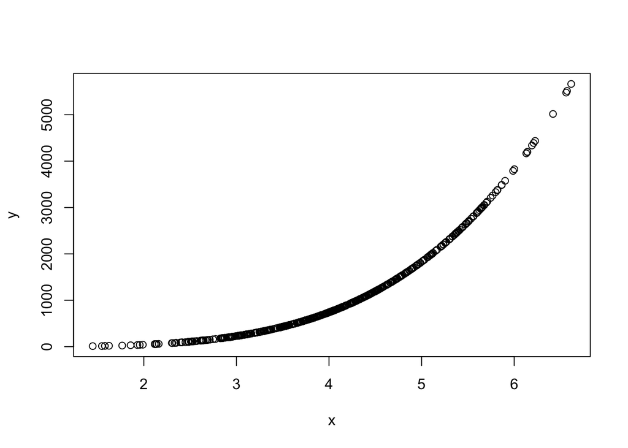

```r
plot(x,y)
```

3. Set the seed to be 23, and then compute the LOOCV and 10-fold CV errors that result from fitting the following four models using least squares:
1. Y = β0 + β1X + ε
2. Y =β0 +β1X+β2X2 +ε
3. Y =β0 +β1X+β2X2 +β3X3 +ε
4. Y =β0 +β1X+β2X2 +β3X3 +β4X4 +ε.

Note you may find it helpful to use the data.frame() function to create a single data set containing both X and Y.

```r
library(boot)
set.seed(23)
y = rnorm(500)
x = 4 - rnorm(500)
y = x - 2*x^2 + 3*x^4 + rnorm(500)
df<-data.frame(x,y)

# first model Y = β0 + β1X + ε
glm.fit <- glm(y~x,data=df)
cv.err <- cv.glm(df,glm.fit)
cv.err2<-cv.glm(df,glm.fit,K=10)
print(paste("The LOOCV error for first model is",cv.err$delta[1]," and the 10th-fold CV error for the first model is",cv.err2$delta[1]))
```

```
## [1] "The LOOCV error for first model is 195337.297150242  and the 10th-fold CV error for the first model is 193314.650140994"
```

```r
# second model Y =β0 +β1X+β2X^2 +ε
glm.fit2<-glm(y~poly(x,2),data=df)
cv.err<-cv.glm(df,glm.fit2)
cv.err2<-cv.glm(df,glm.fit2,K=10)
print(paste("The LOOCV error for second model is",cv.err$delta[1]," and the 10th-fold CV error for the second model is",cv.err2$delta[1]))
```

```
## [1] "The LOOCV error for second model is 11865.4098083307  and the 10th-fold CV error for the second model is 12018.4546211804"
```

```r
# third model Y =β0 +β1X+β2X2 +β3X3 +ε
glm.fit3<-glm(y~poly(x,3),data=df)
cv.err<-cv.glm(df,glm.fit3)
cv.err2<-cv.glm(df,glm.fit3,K=10)
print(paste("The LOOCV error for the third model is",cv.err$delta[1]," and the 10th-fold CV error for the third model is",cv.err2$delta[1]))
```

```
## [1] "The LOOCV error for the third model is 151.481840745373  and the 10th-fold CV error for the third model is 157.890934227381"
```

```r
# fourth model Y =β0 +β1X+β2X2 +β3X3 +β4X4 +ε.
glm.fit4<-glm(y~poly(x,4),data=df)
cv.err<-cv.glm(df,glm.fit4)
cv.err2<-cv.glm(df,glm.fit4,K=10)
print(paste("The LOOCV error for the fourth model is",cv.err$delta[1]," and the 10th-fold CV error for the fourth model is",cv.err2$delta[1]))
```

```
## [1] "The LOOCV error for the fourth model is 1.04678407691068  and the 10th-fold CV error for the fourth model is 1.05923599962819"
```

4. Repeat (c) using random seed 46, and report your results. Are your results the same as what you got in (c)? Why?

**Answer**: The results are the not same as when using `set.seed(23)`, but they are very similar. This is because `set.seed()` generates a random set of numbers.

```r
set.seed(46)
y = rnorm(500)
x = 4 - rnorm(500)
y = x - 2*x^2 + 3*x^4 + rnorm(500)
df<-data.frame(x,y)

# first model Y = β0 + β1X + ε
glm.fit <- glm(y~x,data=df)
cv.err <- cv.glm(df,glm.fit)
cv.err2<-cv.glm(df,glm.fit,K=10)
print(paste("The LOOCV error for first model is",cv.err$delta[1]," and the 10-fold CV error for the first model is",cv.err2$delta[1]))
```

```
## [1] "The LOOCV error for first model is 212789.740894727  and the 10-fold CV error for the first model is 212191.155996556"
```

```r
# second model Y =β0 +β1X+β2X^2 +ε
glm.fit2<-glm(y~poly(x,2),data=df)
cv.err<-cv.glm(df,glm.fit2)
cv.err2<-cv.glm(df,glm.fit2,K=10)
print(paste("The LOOCV error for second model is",cv.err$delta[1]," and the 10th-fold CV error for the second model is",cv.err2$delta[1]))
```

```
## [1] "The LOOCV error for second model is 12646.1993515859  and the 10th-fold CV error for the second model is 13106.3094597804"
```

```r
# third model Y =β0 +β1X+β2X2 +β3X3 +ε
glm.fit3<-glm(y~poly(x,3),data=df)
cv.err<-cv.glm(df,glm.fit3)
cv.err2<-cv.glm(df,glm.fit3,K=10)
print(paste("The LOOCV error for the third model is",cv.err$delta[1]," and the 10th-fold CV error for the third model is",cv.err2$delta[1]))
```

```
## [1] "The LOOCV error for the third model is 134.149872021211  and the 10th-fold CV error for the third model is 137.344748362639"
```

```r
# fourth model Y =β0 +β1X+β2X2 +β3X3 +β4X4 +ε.
glm.fit4<-glm(y~poly(x,4),data=df)
cv.err<-cv.glm(df,glm.fit4)
cv.err2<-cv.glm(df,glm.fit4,K=10)
print(paste("The LOOCV error for the fourth model is",cv.err$delta[1]," and the 10th-fold CV error for the fourth model is",cv.err2$delta[1]))
```

```
## [1] "The LOOCV error for the fourth model is 1.04686061344987  and the 10th-fold CV error for the fourth model is 1.0577263169588"
```

5. Which of the models in (c) had the smallest LOOCV and 10-fold CV error? Is this what you expected? Explain your answer.

**Answer**: The fourth model has the smallest LOOCV and 10-fold CV error. This is what I expected because our model data has a 4th degree polynomial relationship.

6. Comment on the statistical significance of the coefficient estimates that results from fitting each of the models in (c) using least squares. Do these results agree with the conclusions drawn based on the cross-validation results?

**Answer**: Yes, these results agree with the conclusions drawn based on CV results. All coefficients have three stars `***` signs, indicating strong significant of `x` to `y`.

```r
summary(glm.fit)
```

```
##
## Call:
## glm(formula = y ~ x, data = df)
##
## Deviance Residuals:
##    Min      1Q  Median      3Q     Max
## -349.0  -301.3  -167.8   144.4  3183.9
##
## Coefficients:
##             Estimate Std. Error t value Pr(>|t|)
## (Intercept) -2741.39      82.89  -33.07   <2e-16 ***
## x             949.28      19.89   47.72   <2e-16 ***
## ---
## Signif. codes:  0 '***' 0.001 '**' 0.01 '*' 0.05 '.' 0.1 ' ' 1
##
## (Dispersion parameter for gaussian family taken to be 209070.5)
##
##     Null deviance: 580130424  on 499  degrees of freedom
## Residual deviance: 104117107  on 498  degrees of freedom
## AIC: 7548.1
##
## Number of Fisher Scoring iterations: 2
```

```r
summary(glm.fit2)
```

```
##
## Call:
## glm(formula = y ~ poly(x, 2), data = df)
##
## Deviance Residuals:
##     Min       1Q   Median       3Q      Max
## -778.70   -70.31     8.29    65.79   839.64
##
## Coefficients:
##              Estimate Std. Error t value Pr(>|t|)
## (Intercept)  1091.746      4.846  225.30   <2e-16 ***
## poly(x, 2)1 21817.729    108.355  201.35   <2e-16 ***
## poly(x, 2)2  9913.722    108.355   91.49   <2e-16 ***
## ---
## Signif. codes:  0 '***' 0.001 '**' 0.01 '*' 0.05 '.' 0.1 ' ' 1
##
## (Dispersion parameter for gaussian family taken to be 11740.89)
##
##     Null deviance: 580130424  on 499  degrees of freedom
## Residual deviance:   5835220  on 497  degrees of freedom
## AIC: 6109.3
##
## Number of Fisher Scoring iterations: 2
```

```r
summary(glm.fit3)
```

```
##
## Call:
## glm(formula = y ~ poly(x, 3), data = df)
##
## Deviance Residuals:
##     Min       1Q   Median       3Q      Max
## -15.166   -7.535    1.317    6.054  104.395
##
## Coefficients:
##              Estimate Std. Error t value Pr(>|t|)
## (Intercept) 1.092e+03  4.667e-01  2339.1   <2e-16 ***
## poly(x, 3)1 2.182e+04  1.044e+01  2090.5   <2e-16 ***
## poly(x, 3)2 9.914e+03  1.044e+01   949.9   <2e-16 ***
## poly(x, 3)3 2.404e+03  1.044e+01   230.4   <2e-16 ***
## ---
## Signif. codes:  0 '***' 0.001 '**' 0.01 '*' 0.05 '.' 0.1 ' ' 1
##
## (Dispersion parameter for gaussian family taken to be 108.9201)
##
##     Null deviance: 580130424  on 499  degrees of freedom
## Residual deviance:     54024  on 496  degrees of freedom
## AIC: 3770.2
##
## Number of Fisher Scoring iterations: 2
```

```r
summary(glm.fit4)
```

```
##
## Call:
## glm(formula = y ~ poly(x, 4), data = df)
##
## Deviance Residuals:
##     Min       1Q   Median       3Q      Max
## -2.9713  -0.5827  -0.0337   0.6461   3.5006
##
## Coefficients:
##              Estimate Std. Error t value Pr(>|t|)
## (Intercept) 1.092e+03  4.541e-02 24041.6   <2e-16 ***
## poly(x, 4)1 2.182e+04  1.015e+00 21486.5   <2e-16 ***
## poly(x, 4)2 9.914e+03  1.015e+00  9763.2   <2e-16 ***
## poly(x, 4)3 2.404e+03  1.015e+00  2367.9   <2e-16 ***
## poly(x, 4)4 2.313e+02  1.015e+00   227.8   <2e-16 ***
## ---
## Signif. codes:  0 '***' 0.001 '**' 0.01 '*' 0.05 '.' 0.1 ' ' 1
##
## (Dispersion parameter for gaussian family taken to be 1.031068)
##
##     Null deviance: 5.8013e+08  on 499  degrees of freedom
## Residual deviance: 5.1038e+02  on 495  degrees of freedom
## AIC: 1441.2
##
## Number of Fisher Scoring iterations: 2
```